# SDM Evaluation Tool Report

# Settings

# Predictions

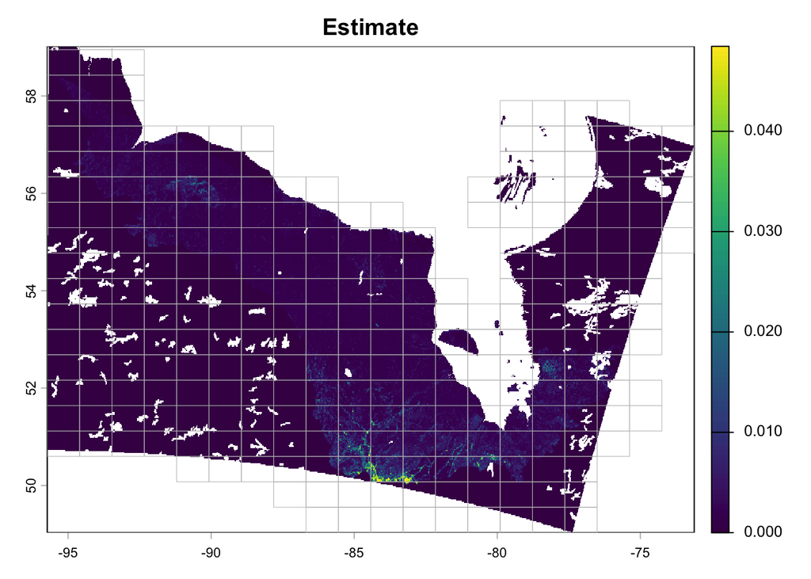

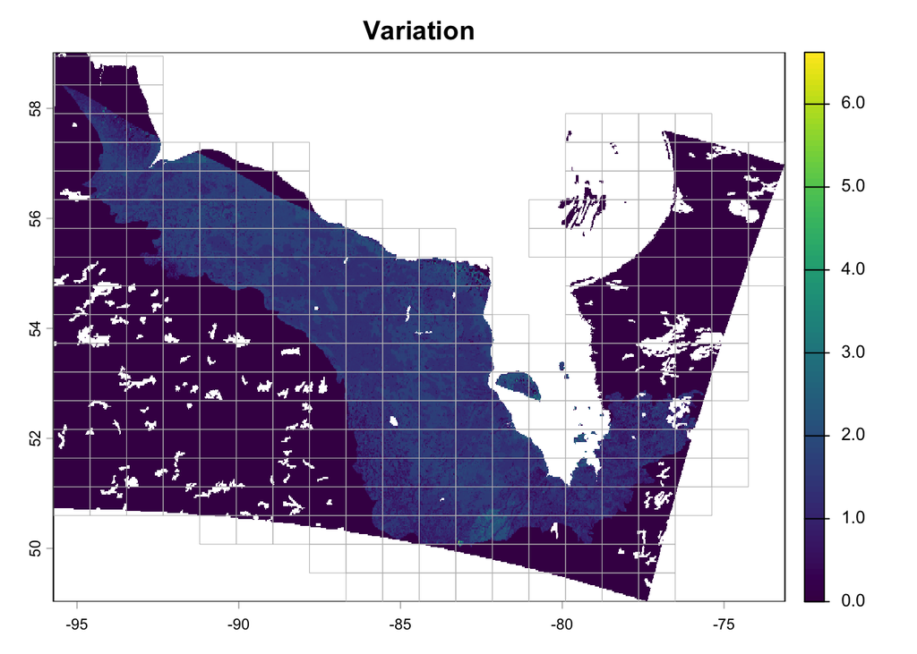

#### Question 1

**Question**: Identify the areas on the map where predictions are inaccurate.

**Answer**:

| values | subunits |
| --- | --- |
| Severe over | 51, 52 |
| Moderate over | NULL |
| Accurate | NULL |
| Moderate under | NULL |
| Severe under | NULL |
| Unknown | NULL |

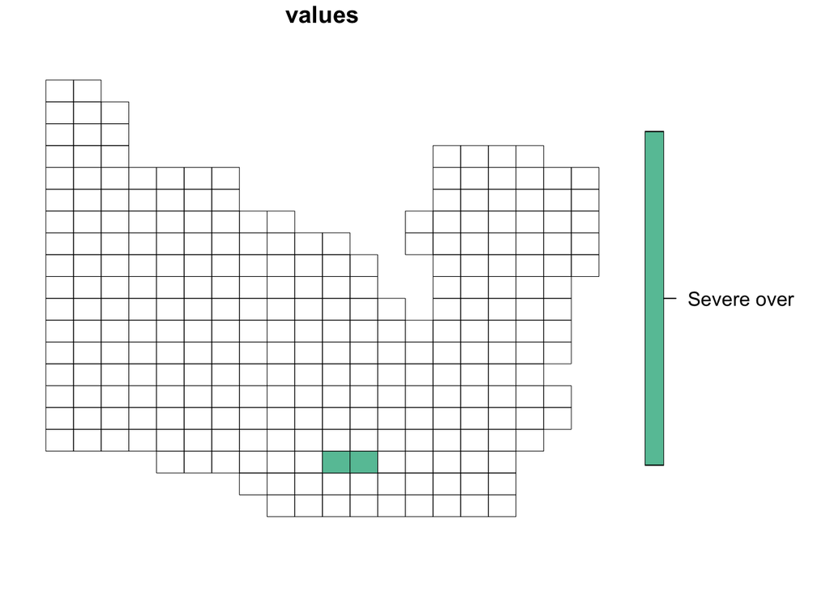

#### Question 2

**Question**: Identify areas on the map where uncertainty does not align with your understanding of data limitations, known habitat complexities, or other sources of uncertainty.

**Answer**:

| values | subunits |
| --- | --- |
| Too high | NULL |
| Accurate | 111, 112, 130, 131, 132 |
| Unknown | NULL |

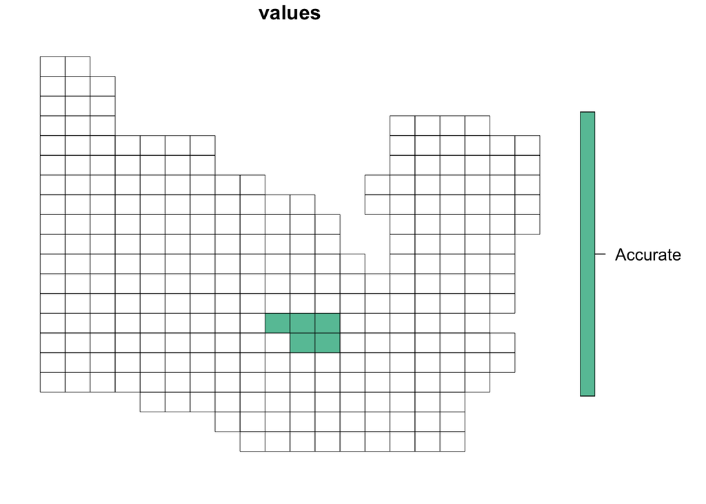

# Observations

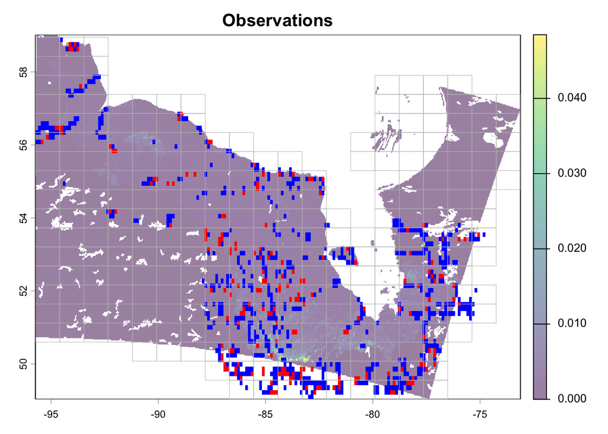

#### Question 1

**Question**: Are there areas where you are concerned about potential bias in the data? Identify areas with potential bias in the data.

**Answer**:

| values | subunits |
| --- | --- |
| Very biased | NULL |
| Moderately biased | NULL |
| Accurate | 91 , 92 , 130 |
| Unknown | NULL |

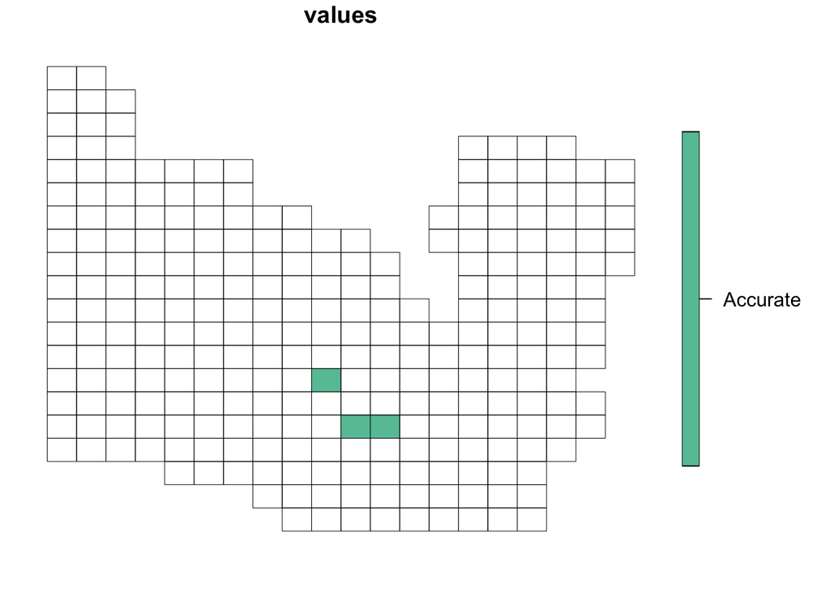

#### Question 2

**Question**: Are there areas where this species is not sufficiently sampled? Identify areas that are not sufficiently sampled.

**Answer**:

| values | subunits |
| --- | --- |
| Very undersampled | NULL |
| Moderately undersampled | NULL |
| Accurate | 91 , 92 , 130 |
| Unknown | NULL |

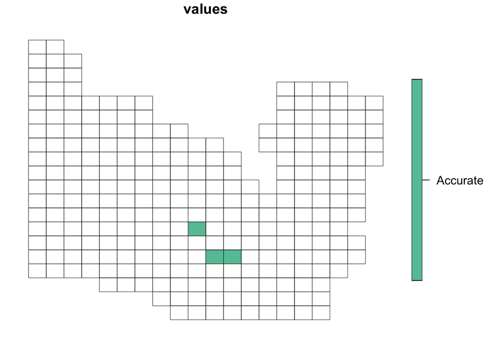

#### Question 3

**Question**: How concerned are you about the distribution of counts?

**Answer**: Not at all

#### Question 4

**Question**: If so, explain. What is an appropriate truncation values (i.e. highest count)?

**Answer**:

#### Question 5

**Question**: How concerned are you about the temporal distribution of detections?

**Answer**: Slightly

#### Question 6

**Question**: If so, explain. What is an appropriate truncation values (i.e. minimum year)?

**Answer**: Seems off

#### Question 7

**Question**: How concerned are you about the description and treatment of potential biases in the data, as described in the model metadata?

**Answer**: Uncertain

# Model Summary

| predictor | mean_rel_inf | sd_rel_inf | n_boots | predictor_class |
| --- | --- | --- | --- | --- |
| SCANFIheightcv_1km | 9.7395678 | 3.3514974 | 32 | Veg Structure |
| SCANFIBalsamFir_1km | 9.0467618 | 1.9116649 | 32 | Veg Species |
| Year | 7.0502880 | 1.6359048 | 32 | Time |
| SCANFIheight_1km | 5.9968674 | 1.4617367 | 32 | Veg Structure |
| MODISLCC_1km | 5.2292118 | 1.5468278 | 32 | Landcover |
| DD18_1km | 3.3860959 | 1.6664503 | 32 | Climate Normals |
| mTPI_1km | 2.9858232 | 0.8745256 | 32 | Topography |
| StandardDormancy_1km | 2.9339794 | 3.2322455 | 32 | Annual Climate |
| WetSeason_1km | 2.7975554 | 1.1976300 | 32 | Wetland |
| WetOccur_5x5 | 2.7587181 | 1.0518024 | 32 | Wetland |
| SCANFIheight_5x5 | 2.5985967 | 2.1752826 | 32 | Veg Structure |
| SCANFIheightcv_5x5 | 2.4633486 | 1.3360881 | 32 | Veg Structure |
| LakeEdge_1km | 2.4609141 | 0.9936193 | 32 | Wetland |
| SCANFIBalsamFir_5x5 | 2.3850859 | 0.9926585 | 32 | Veg Species |
| SCANFIprcC_1km | 2.2973890 | 1.3659295 | 32 | Veg Species |
| canroad_5x5 | 2.2508547 | 0.8453557 | 32 | Disturbance |
| SCANFIprcD_5x5 | 2.2301917 | 0.8744424 | 32 | Veg Species |
| WetRecur_1km | 1.7174033 | 1.2294058 | 32 | Wetland |
| SCANFIJackPine_1km | 1.6927073 | 0.7825271 | 32 | Veg Species |
| ERATavewt_1km | 1.5350716 | 0.7656798 | 32 | Annual Climate |
| SCANFIprcD_1km | 1.4738463 | 0.7073679 | 32 | Veg Species |
| ERAMAP_1km | 1.4080462 | 0.8899619 | 32 | Annual Climate |
| roughness_1km | 1.3408574 | 0.4801713 | 32 | Topography |
| SCANFIWhiteRedPine_5x5 | 1.2897805 | 0.6036205 | 32 | Veg Species |
| StandardGreenup_1km | 1.1823259 | 0.8047980 | 32 | Annual Climate |
| Peatland_1km | 1.1603035 | 0.5586948 | 32 | Wetland |
| SCANFITamarack_5x5 | 1.1413561 | 0.5187234 | 32 | Veg Species |
| CanHF_5x5 | 1.1317059 | 0.4981087 | 32 | Disturbance |
| canroad_1km | 1.0518417 | 0.4722718 | 32 | Disturbance |
| AHM_1km | 1.0467066 | 0.4706174 | 32 | Climate Normals |
| SCANFITamarack_1km | 1.0290594 | 0.5694791 | 32 | Veg Species |
| ERAPPTwt_1km | 1.0179091 | 0.7590603 | 32 | Annual Climate |
| SCANFIBlackSpruce_1km | 0.9978780 | 0.4941300 | 32 | Veg Species |
| SCANFIprcC_5x5 | 0.9872653 | 0.5336337 | 32 | Veg Species |
| ERATavesm_1km | 0.9676469 | 0.7654963 | 32 | Annual Climate |
| MODISLCC_5x5 | 0.9628885 | 0.5574323 | 32 | Landcover |
| CanHF_1km | 0.8997146 | 0.3825675 | 32 | Disturbance |
| SCANFIWhiteRedPine_1km | 0.8308087 | 0.6975852 | 32 | Veg Species |
| ERAMAT_1km | 0.7956727 | 0.4225823 | 32 | Annual Climate |
| ERATavesmt_1km | 0.7588200 | 0.4130412 | 32 | Annual Climate |
| NFFD_1km | 0.7527604 | 0.3768080 | 32 | Climate Normals |
| SCANFIJackPine_5x5 | 0.7132362 | 0.3059725 | 32 | Veg Species |
| ERAPPTsmt_1km | 0.7079720 | 0.3328948 | 32 | Annual Climate |
| TD_1km | 0.6629251 | 0.3543668 | 32 | Climate Normals |
| VLCE_1km | 0.5833038 | 0.3278370 | 32 | Landcover |
| ERAPPTsm_1km | 0.5809662 | 0.3254851 | 32 | Annual Climate |
| CCNL_1km | 0.5306605 | 0.3347241 | 32 | Disturbance |
| PPTsm_1km | 0.4373108 | 0.2391960 | 32 | Climate Normals |

#### Question 1

**Question**: How concerned are you about missing predictor interactions or nonlinear relationships?

**Answer**: Slightly

#### Question 2

**Question**: What interactions or nonlinear relationships are missing?

**Answer**: Check.

#### Question 3

**Question**: How concerned are your about the reported relative importance of predictors?

**Answer**: Extremely

#### Question 4

**Question**: Which predictors would you expect to be more or less important and why?

#### Question 5

**Question**: How concerned are you about the appropriateness of the modeling algorithm for the model objectives and application?

**Answer**: Very

#### Question 6

**Question**: How concerned are you about how well the modelling framework addresses important statistical assumptions?

**Answer**: Moderately

#### Question 7

**Question**: How concerned are you about how well important biological assumptions are explained and justified?

**Answer**: Slightly

#### Question 8

**Question**: What other concerns or comments do you have about model complexity?

**Answer**: None

#### Question 9

**Question**: How concerned are you about missing predictor interactions or nonlinear relationships?

**Answer**: Very

#### Question 10

**Question**: What interactions or nonlinear relationships are missing?

**Answer**:

#### Question 11

**Question**: How concerned are your about the reported relative importance of predictors?

**Answer**:

#### Question 12

**Question**: Which predictors would you expect to be more or less important and why?

**Answer**:

#### Question 13

**Question**: How concerned are you about the appropriateness of the modeling algorithm for the model objectives and application?

**Answer**:

#### Question 14

**Question**: How concerned are you about how well the modelling framework addresses important statistical assumptions?

**Answer**:

#### Question 15

**Question**: How concerned are you about how well important biological assumptions are explained and justified?

**Answer**:

#### Question 16

**Question**: What other concerns or comments do you have about model complexity?

**Answer**:

# Model Fit

| metric | value |
| --- | --- |
| prevalence | 0.0257576 |
| run_complete | 32.0000000 |
| AUC_init | 0.5944797 |
| AUC_final | 0.9316114 |
| pseudo_R2 | 0.2244647 |
| occc | 0.5901399 |
| oprec | 0.6497372 |
| oaccu | 0.9082747 |

#### Question 1

**Question**: How concerned are you about the adequacy or appropriateness of the validation metrics?

**Answer**: Not at all

#### Question 2

**Question**: What are the metrics that should be used and why?

**Answer**: BIC

#### Question 3

**Question**: What other concerns do you have about model performance?

**Answer**: None

#### Question 4

**Question**: How concerned are you about the adequacy or appropriateness of the validation metrics?

**Answer**: Very

#### Question 5

**Question**: What are the metrics that should be used and why?

**Answer**:

#### Question 6

**Question**: What other concerns do you have about model performance?

# Predictor Raster

#### Question 1

**Question**: How concerned are you about inaccuracy in the model predictors?

**Answer**: Not at all

#### Question 2

**Question**: If so, describe the predictor(s) and the areas of concern.

**Answer**:

#### Question 3

**Question**: How concerned are you about the spatial resolution of the predictor variables?

**Answer**: Moderately

# Predictor Metadata

#### Question 1

**Question**: How concerned are you about missing predictors?

**Answer**: Uncertain

#### Question 2

**Question**: What predictors are missing and why?

**Answer**: Seems fine

#### Question 3

**Question**: How concerned are you about superfluous or inappropriate predictors?

**Answer**: Slightly

#### Question 4

**Question**: Which predictors should be removed and why?